# Evaluación de la oferta inmobiliaria urbana

Oscar Mauricio Montaño

[figure not shown]

## 1 Problema

Una empresa inmobiliaria líder en una gran ciudad está buscando comprender en profundidad el mercado de viviendas urbanas para tomar decisiones estratégicas más informadas. La empresa posee una base de datos extensa que contiene información detallada sobre diversas propiedades residenciales disponibles en el mercado. Se requiere realizar un análisis holístico de estos datos para identificar patrones, relaciones y segmentaciones relevantes que permitan mejorar la toma de decisiones en cuanto a la compra, venta y valoración de propiedades.

## 2 Análisis exploratorio

### 2.1 Tipo de datos de las variables

```r
data("vivienda")
df <- vivienda

#dplyr::glimpse(df)

tabla_glimpse <- data.frame(
  Variable = names(df),
  Tipo = sapply(df, function(x) class(x)[1]),
  Ejemplo = sapply(df, function(x) {
    paste(head(x, 3), collapse = ", ")
  }),
  row.names = NULL
)
tabla_glimpse %>%
  knitr::kable("html", booktabs = TRUE,
               caption = "<span style='font-size:13pt; font-weight:bold;'>Tabla 1. Resumen del tipo de dato</span>") %>%
  kable_styling(full_width = FALSE,
                position = "center",
                bootstrap_options = c("striped", "hover")) %>%
  column_spec(1, bold = TRUE, width = "8cm") %>%
  row_spec(0, bold = TRUE, background = "#f2f2f2")
```

Tabla 1. Resumen del tipo de dato

| Variable | Tipo | Ejemplo |
| --- | --- | --- |
| id | numeric | 1147, 1169, 1350 |
| zona | character | Zona Oriente, Zona Oriente, Zona Oriente |
| piso | character | NA, NA, NA |
| estrato | numeric | 3, 3, 3 |
| preciom | numeric | 250, 320, 350 |
| areaconst | numeric | 70, 120, 220 |
| parqueaderos | numeric | 1, 1, 2 |
| banios | numeric | 3, 2, 2 |
| habitaciones | numeric | 6, 3, 4 |
| tipo | character | Casa, Casa, Casa |
| barrio | character | 20 de julio, 20 de julio, 20 de julio |
| longitud | numeric | -76.51168, -76.51237, -76.51537 |
| latitud | numeric | 3.43382, 3.43369, 3.43566 |

### 2.2 Resumen del set de datos

```r
tabla_summary <- df %>%
  select(-id, -longitud, -latitud) %>%        # eliminar id si existe
  select(where(is.numeric)) %>%    # SOLO numéricas
  summarise(
    across(
      everything(),
      list(
        N = ~sum(!is.na(.x)),
        Min = ~min(.x, na.rm = TRUE),
        `1st Qu.` = ~quantile(.x, 0.25, na.rm = TRUE),
        Median = ~median(.x, na.rm = TRUE),
        Mean = ~mean(.x, na.rm = TRUE),
        `3rd Qu.` = ~quantile(.x, 0.75, na.rm = TRUE),
        Max = ~max(.x, na.rm = TRUE)
      ),
      .names = "{.col}__{.fn}"     # separador seguro
    )
  ) %>%
  pivot_longer(
    cols = everything(),
    names_to = c("Variable", ".value"),
    names_pattern = "(.*)__(.*)"
  ) %>%
  select(Variable, N, Min, `1st Qu.`, Median, Mean, `3rd Qu.`, Max)
# Ordenar columnas (Variable, N, resto)
tabla_summary <- tabla_summary %>%
  select(Variable, N, Min, `1st Qu.`, Median, Mean, `3rd Qu.`, Max)

tabla_summary %>%
  knitr::kable("html", booktabs = TRUE,
               caption = "<span style='font-size:13pt; font-weight:bold;'>Tabla 2. Resumen de estadísticas descriptivas de variables numéricas</span>") %>%
  kable_styling(full_width = FALSE,
                position = "center",
                bootstrap_options = c("striped", "hover")) %>%
  column_spec(1, bold = TRUE, width = "8cm") %>%
  row_spec(0, bold = TRUE, background = "#f2f2f2")
```

Tabla 2. Resumen de estadísticas descriptivas de variables numéricas

| Variable | N | Min | 1st Qu. | Median | Mean | 3rd Qu. | Max |
| --- | --- | --- | --- | --- | --- | --- | --- |
| estrato | 8319 | 3 | 4 | 5 | 4.633610 | 5 | 6 |
| preciom | 8320 | 58 | 220 | 330 | 433.891947 | 540 | 1999 |
| areaconst | 8319 | 30 | 80 | 123 | 174.934938 | 229 | 1745 |
| parqueaderos | 6717 | 1 | 1 | 2 | 1.835194 | 2 | 10 |
| banios | 8319 | 0 | 2 | 3 | 3.111311 | 4 | 10 |
| habitaciones | 8319 | 0 | 3 | 3 | 3.605361 | 4 | 10 |

### 2.3 Valores faltantes

```r
tabla_na <- df %>%
  select(-any_of("id")) %>%
  summarise(
    across(
      everything(),
      ~sum(is.na(.x))
    )
  ) %>%
  t() %>%
  as.data.frame()

tabla_na <- tabla_na %>%
  tibble::rownames_to_column("Variable") %>%
  rename(N_Faltantes = V1) %>%   # <- aquí el cambio
  mutate(
    Total = nrow(df),
    Porcentaje_NA = round((N_Faltantes / Total) * 100, 2)
  )


tabla_na %>%
  kable("html", booktabs = TRUE,
        caption = "<span style='font-size:13pt; font-weight:bold;'>Tabla 3. Valores faltantes por variable</span>",
        digits = 2) %>%
  kable_styling(full_width = FALSE,
                position = "center",
                bootstrap_options = c("striped", "hover")) %>%
  column_spec(1, bold = TRUE, width = "5cm") %>%
  row_spec(0, bold = TRUE, background = "#f2f2f2")
```

Tabla 3. Valores faltantes por variable

| Variable | N_Faltantes | Total | Porcentaje_NA |
| --- | --- | --- | --- |
| zona | 3 | 8322 | 0.04 |
| piso | 2638 | 8322 | 31.70 |
| estrato | 3 | 8322 | 0.04 |
| preciom | 2 | 8322 | 0.02 |
| areaconst | 3 | 8322 | 0.04 |
| parqueaderos | 1605 | 8322 | 19.29 |
| banios | 3 | 8322 | 0.04 |
| habitaciones | 3 | 8322 | 0.04 |
| tipo | 3 | 8322 | 0.04 |
| barrio | 3 | 8322 | 0.04 |
| longitud | 3 | 8322 | 0.04 |
| latitud | 3 | 8322 | 0.04 |

De acuerdo con la tabla 3, las variables con más valores faltantes son: piso y parqueaderos. La variable piso no se considerará para el presente estudio ya que presenta 31.70 % de valores faltantes frente al total de registros, y no se tiene una idea clara de qué tipo de técnica de imputación se podría utilizar.

### 2.4 Matriz de Correlaciones

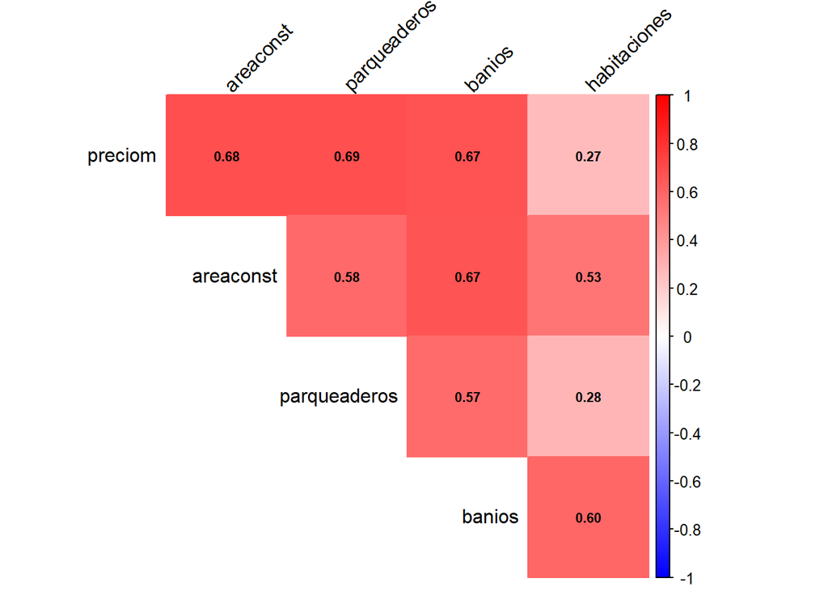

```r
#Elimino valores faltantes en la columna zona (3)
df_sin_zona <- df %>%
  filter(!is.na(zona))

df_num <- df_sin_zona %>%
  select(where(is.numeric), -latitud, -longitud,-id, -estrato)

matriz_cor <- cor(df_num, use = "complete.obs", method = "pearson")

# Ajustar márgenes (más espacio abajo)
par(mar = c(3, 1, 2, 1))

corrplot(
  matriz_cor,
  method = "color",        # colores
  type = "upper",          # solo triángulo superior (más limpio)
  addCoef.col = "black",   # números dentro de las celdas
  tl.col = "black",        # color de etiquetas
  tl.srt = 45,             # rotar nombres de variables
  number.cex = 0.7,        # tamaño de los números
  col = colorRampPalette(c("blue", "white", "red"))(200), # paleta
  diag = FALSE
)
```

**Figura 1.0 Correlaciones de Pearson. Azul = relación negativa, rojo = positiva. Solo variables numéricas**

De acuerdo con la figura 1, la variable preciom presenta correlaciones cercanas al 70 % con las variables: área construida, parqueaderos y baños, por lo que se vislumbran como variables influyentes en el precio de la vivienda, y por tanto deben tenerse en cuenta dentro del presente estudio.

### 2.5 Histograma de precios

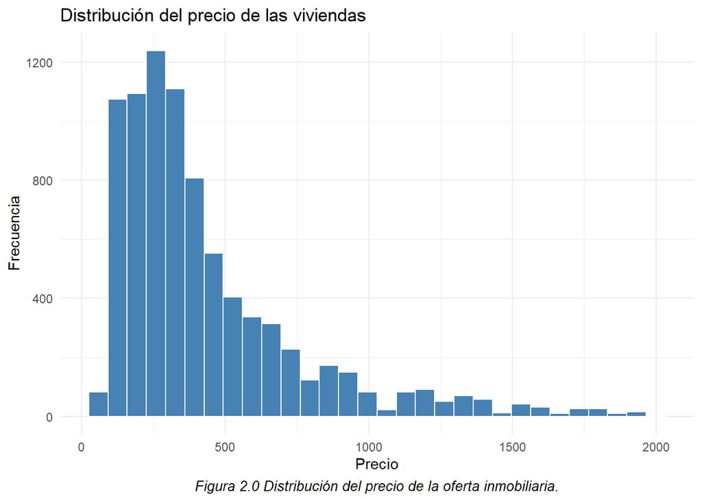

```r
ggplot(df, aes(x = preciom)) +
  geom_histogram(bins = 30, fill = "steelblue", color = "white") +
  labs(
    title = "Distribución del precio de las viviendas",
    x = "Precio",
    y = "Frecuencia",
    caption = "Figura 2.0 Distribución del precio de la oferta inmobiliaria."
  ) +
  theme_minimal() +
  theme(
    plot.caption = element_text(
      hjust = 0.5,
      face = "italic",
      size = 10
    )
  )
```

La figura 2 muestra la distribución de los precios de las viviendas. En esta se observa una distribución asimétrica con cola hacia la derecha, evidencia de precios muy altos que podrían considerarse como atípicos estadísticamente, pero plausibles en lo que respecta a este tipo de estudios inmobiliarios. La mayor concentración de observaciones se localiza en el rango de 100 a 400 unidades monetarias, con una frecuencia máxima superior a 1,200 viviendas.

### 2.6 Precio vs Zona

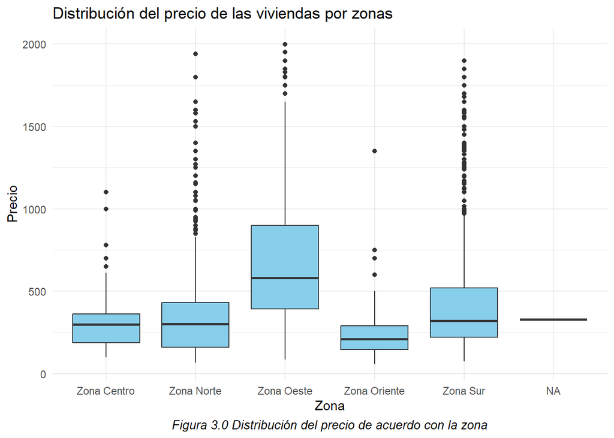

```r
ggplot(df, aes(x = zona, y = preciom)) +
  geom_boxplot(fill = "skyblue") +
  labs(
    title = "Distribución del precio de las viviendas por zonas",
    x = "Zona",
    y = "Precio",
    caption = "Figura 3.0 Distribución del precio de acuerdo con la zona"
  ) +
  theme_minimal() +
  theme(
    plot.caption = element_text(
      hjust = 0.5,
      face = "italic",
      size = 10
    )
  )
```

De acuerdo con la figura 3, se observa lo siguiente:

- la Zona Oeste exhibe la mediana más alta (aproximadamente 600 unidades) y el rango intercuartílico (IQR) más amplio, indicando mayor heterogeneidad en la oferta y precios generalmente superiores.
- Zona Oriente presenta la mediana más baja (alrededor de 200 unidades) y la menor dispersión, sugiriendo un mercado más homogéneo y accesible.
- Zona Centro, Norte y Sur muestran medianas similares (200-300 unidades) con dispersiones comparables.

Lo anterior permite vislumbrar una fuerte influencia de la variable zona respecto del precio de las viviendas, por eso será incluida.

### 2.7 Precio vs Área Construida por tipo de viviendas

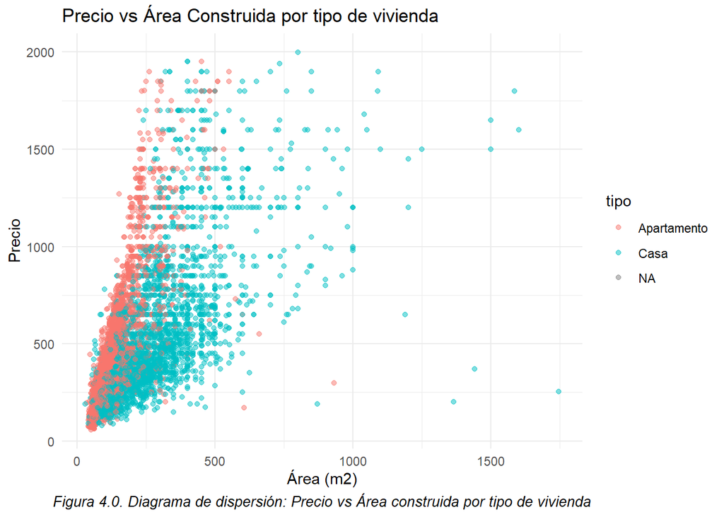

```r
ggplot(df, aes(x = areaconst, y = preciom, color = tipo)) +
  geom_point(alpha = 0.5) +
   labs(
    title = "Precio vs Área Construida por tipo de vivienda",
    x = "Área (m2)",
    y = "Precio",
    caption = "Figura 4.0. Diagrama de dispersión: Precio vs Área construida por tipo de vivienda"
  ) +
  theme_minimal() +
  theme(
    plot.caption = element_text(
      hjust = 0.5,
      face = "italic",
      size = 10
    )
  )
```

La figura 4.0 evidencia una relación positiva entre el área construida y el precio, aunque con una dispersión creciente a medida que aumenta el tamaño del inmueble, lo que sugiere la influencia de factores adicionales como el estrato y la ubicación. Se observa una clara segmentación por tipo de vivienda: los apartamentos se concentran en áreas menores y precios medios, mientras que las casas dominan el segmento de mayor tamaño y presentan mayor heterogeneidad de precios. Asimismo, se identifican valores atípicos que podrían corresponder a propiedades de lujo (precios muy altos con áreas reducidas) o inconsistencias en los datos (precios bajos para viviendas con áreas muy grandes), lo que justifica la aplicación de técnicas de detección de outliers.

### 2.8 Precio vs Número de habitaciones

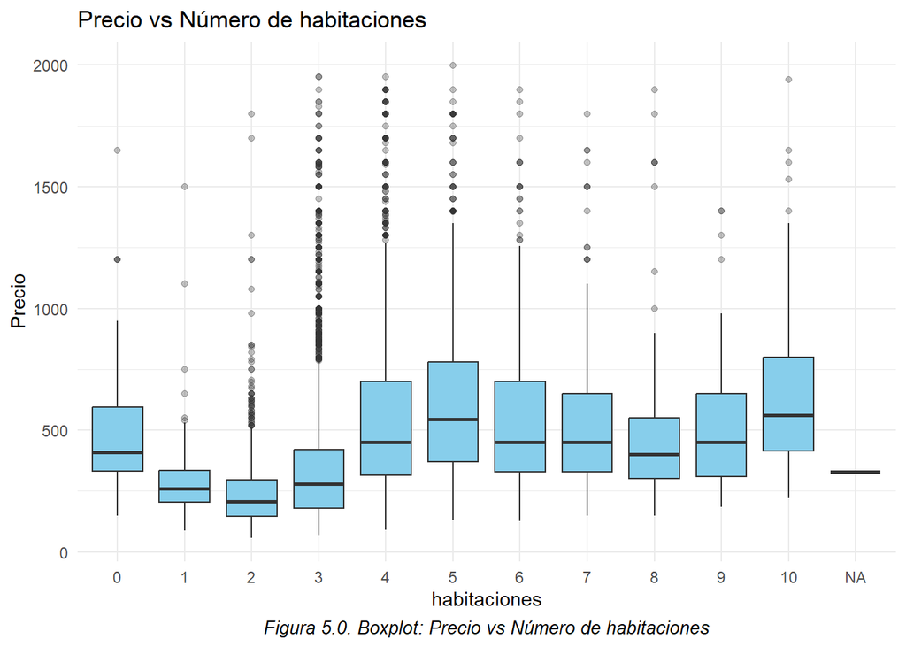

```r
ggplot(df, aes(x = factor(habitaciones), y = preciom)) +
  geom_boxplot(outlier.alpha = 0.3, fill = "skyblue") +
  labs(
    title = "Precio vs Número de habitaciones",
    x = "habitaciones",
    y = "Precio",
    caption = "Figura 5.0. Boxplot: Precio vs Número de habitaciones"
  ) +
  theme_minimal() +
  theme(
    plot.caption = element_text(
      hjust = 0.5,
      face = "italic",
      size = 10
    )
  )
```

Al revisar los precios de viviendas de acuerdo con el número de habitaciones (figura 5.0), es preciso afirmar que las viviendas con 1 y 2 habitaciones son las de menor valor de la precio (mediana), sin embargo, se observan muchos valores extremos entre 2 y 7 habitaciones. Esto se podría explicar por:

- Mayor variedad de calidad y ubicación.
- Influencia de estrato y área construida.
- Segmento de lujo más diverso.

### 2.9 Precio vs Estrato

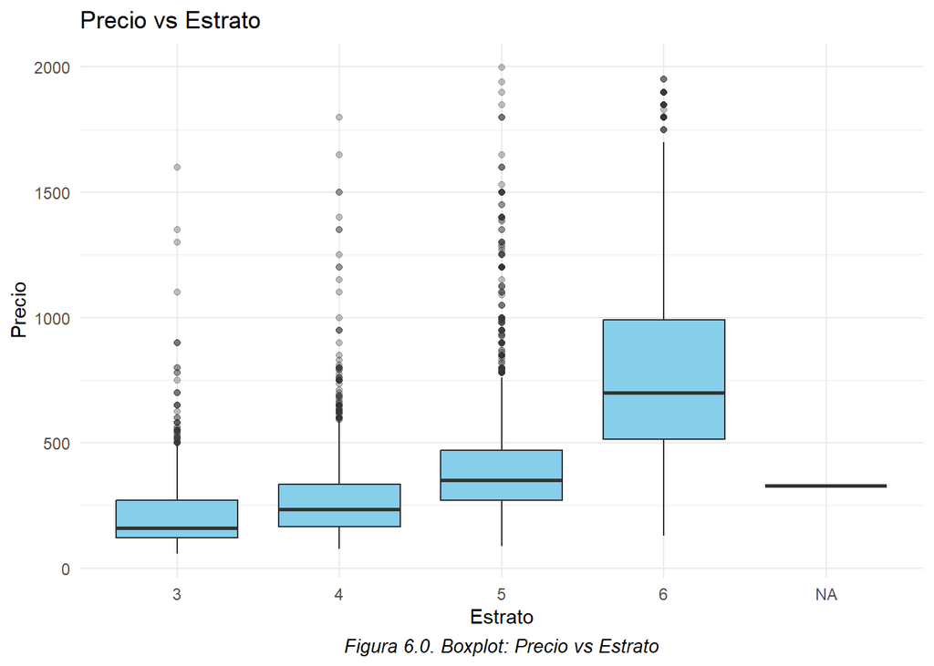

```r
ggplot(df, aes(x = factor(estrato), y = preciom)) +
  geom_boxplot(outlier.alpha = 0.3, fill = "skyblue") +
 labs(
    title = "Precio vs Estrato",
    x = "Estrato",
    y = "Precio",
    caption = "Figura 6.0. Boxplot: Precio vs Estrato"
  ) +
  theme_minimal() +
  theme(
    plot.caption = element_text(
      hjust = 0.5,
      face = "italic",
      size = 10
    )
  )
```

La figura 6.0 refleja la influencia importante del estrato en el precio de la vivienda. Los estratos 5 y 6 presentan los precios más altos. Es preciso mencionar que en todos los estratos se evidencian valores atípicos que pueden ser plausibles por la heterogeneidad de viviendas.

### 2.10 Precio por ubicación geográfica y estrato

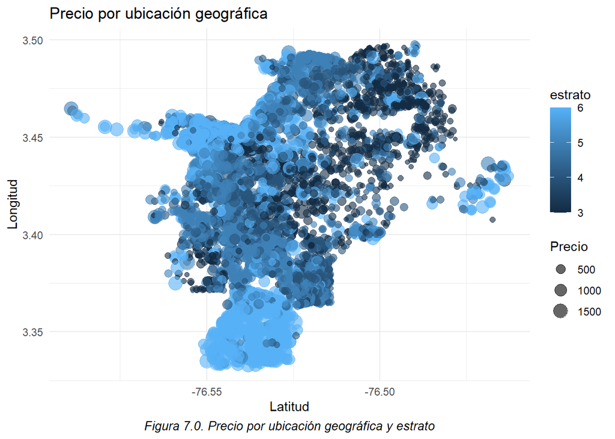

```r
ggplot(df, aes(x = longitud, y = latitud,
               color = estrato,
               size = preciom)) +
  geom_point(alpha = 0.6) +
  scale_size_continuous(
    range = c(1, 6),          # puntos pequeños → grandes bien diferenciados
    name = "Precio"
  ) +
  labs(
    title = "Precio por ubicación geográfica",
    x = "Latitud",
    y = "Longitud",
    caption = "Figura 7.0. Precio por ubicación geográfica y estrato"
  ) +
  theme_minimal() +
  theme(
    plot.caption = element_text(
      hjust = 0.5,
      face = "italic",
      size = 10
    )
  )
```

La figura 7.0 muestra que las viviendas de mayor precio (estratos: 5 y 6) se encuentran en el sur, oriente y occidente. En la zona centro se observa mayor heterogenidad de precios, esto se puede justificar por la variedad del tipo de vivienda: edificios, casas y apartamentos.

## 3 Transformación de datos

Se decide eliminar los registros 8320, 8321 y 8322, ya que no se tiene suficiente información.

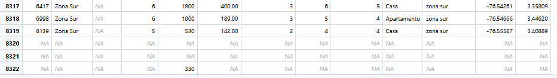

Figura 8.0. Registros eliminados del dataset

Adicionalmente, se transforman a tipo factor las siguientes variables: parqueaderos, piso, zona, tipo y barrio. Finalmente, los valores faltantes de estas variables categóricas, se llenan como “No informado”.

```r
#df_sin_zona

df_piso_parq <- df_sin_zona %>%
  mutate(
    piso = ifelse(is.na(piso), "No informado", piso),
    parqueaderos = ifelse(is.na(parqueaderos), "No informado", parqueaderos),
    piso = as.factor(piso),
    parqueaderos = as.factor(parqueaderos),
    zona   = as.factor(zona),
    tipo   = as.factor(tipo),
    barrio = as.factor(barrio)
    )
```

## 4 Análisis de Componentes Principales (ACP)

### 4.1 Círculo de correlaciones del Análisis de Componentes Principales (PCA)

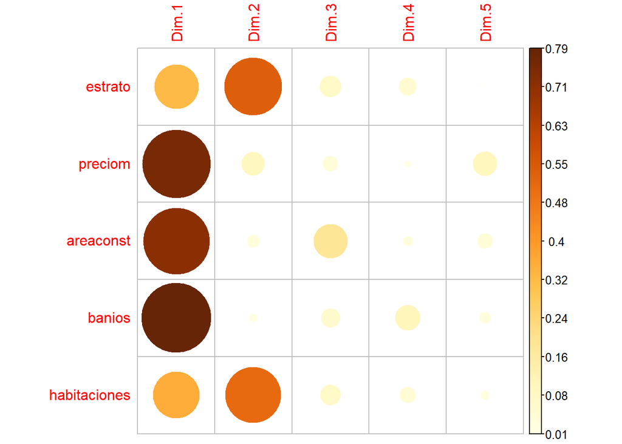

```r
id_vector <- df_piso_parq$id

df_sin_coord <- df_piso_parq %>%
  select(-longitud, -latitud)

pca_model_FactorM <- PCA(
  df_sin_coord %>% select(-id),
  ncp = 5,
  quali.sup = which(sapply(df_sin_coord %>% select(-id), is.factor)),
  scale.unit = TRUE,
  graph = FALSE
)

var <- get_pca_var(pca_model_FactorM)

corrplot::corrplot(var$cos2, is.corr=FALSE)
```

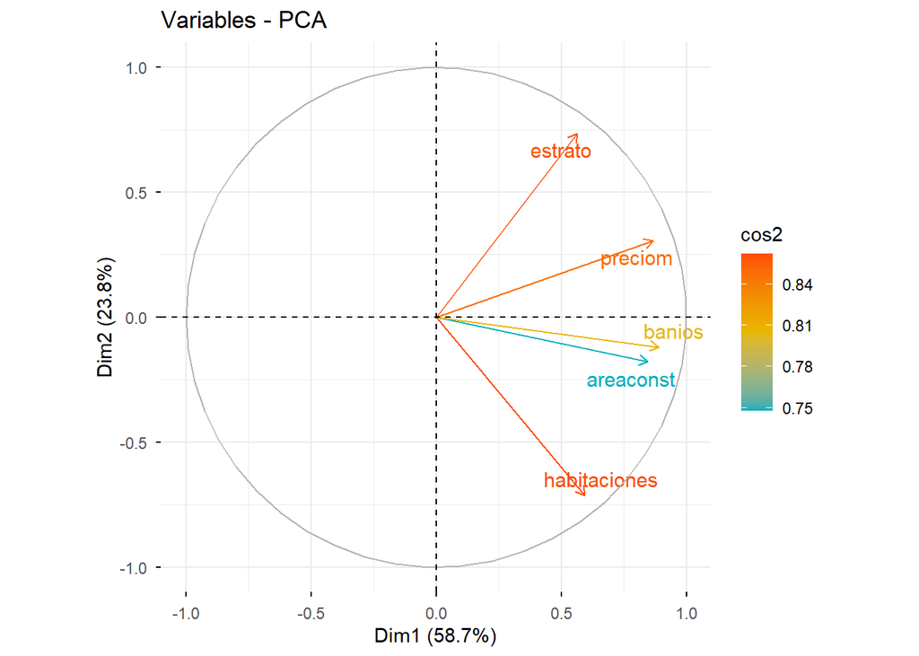

```r
fviz_pca_var(pca_model_FactorM, col.var = "cos2",
             gradient.cols = c("#00AFBB", "#E7B800", "#FC4E07"),
             repel = TRUE # Avoid text overlapping
)
```

**Figura 8.0. Círculo de correlaciones del Análisis de Componentes Principales (PCA)**

La figura 8 muestra que el primer componente principal está asociado al nivel general del inmueble, integrando variables de tamaño (área construida, número de baños y habitaciones), precio y estrato socioeconómico. El segundo componente diferencia entre viviendas de mayor número de habitaciones y aquellas de mayor estrato, lo que sugiere la existencia de tipologías distintas dentro del mercado inmobiliario, como viviendas familiares amplias y propiedades de alto valor en estratos superiores con menor número de habitaciones. La proximidad entre las variables de área construida y número de baños evidencia una alta correlación positiva, indicando que los inmuebles de mayor tamaño tienden a contar con más servicios.

### 4.2 Explícación de la varianza total

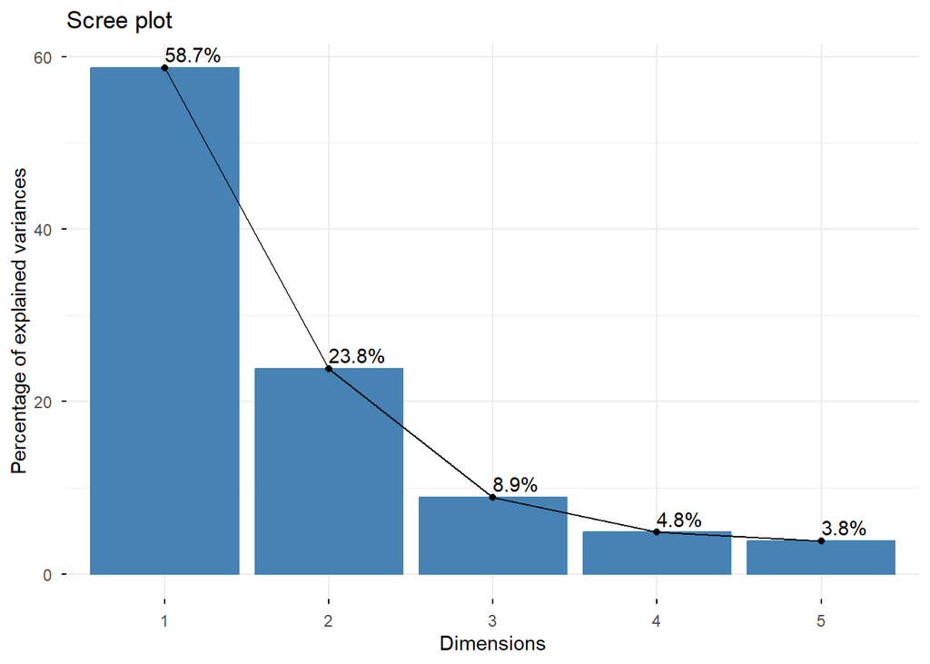

```r
fviz_eig(pca_model_FactorM, addlabels = TRUE)
```

**Figura 9.0. Explicación de la varianza**

La figura 9 muestra que el 82.5 % de la varianza, se explica a través de las dos primeras dimensiones, por lo que solo se tendrán en cuenta estas para el análisis.

### 4.3 Contribuciones individuales de la dimensión 1

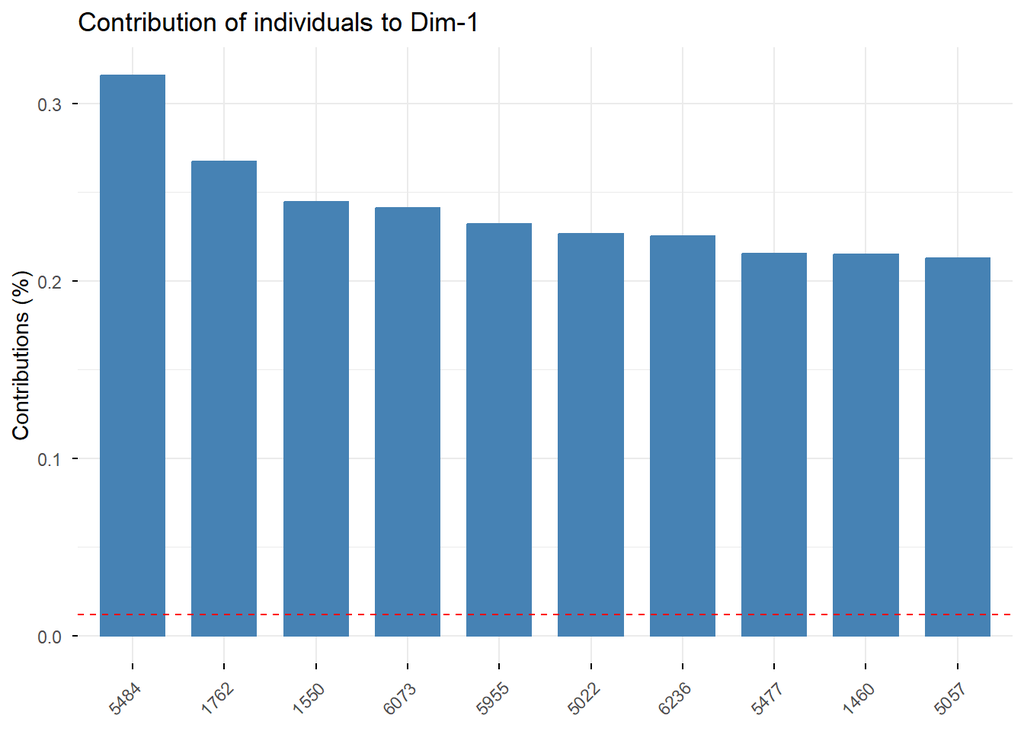

```r
fviz_contrib(pca_model_FactorM,choice = "ind", axes=1, top = 10)
```

**Figura 10. Contribuciones individuales de la dimensión 1**

### 4.4 Contribuciones individuales de la dimensión 2

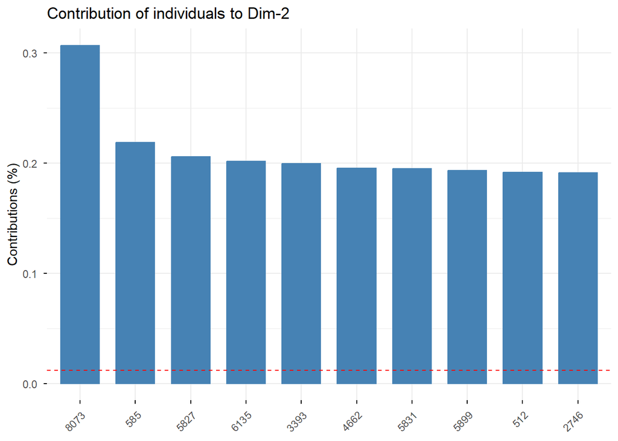

```r
fviz_contrib(pca_model_FactorM,choice = "ind", axes=2, top = 10)
```

**Figura 11. Contribuciones individuales de la dimensión 2**

## 5 Análisis de Conglomerados

### 5.1 Clúster

Para este apartado se usa la función: HCPC (Hierarchical Clustering on Principal Components), de la librería FactoMineR, la cual combina reducción de dimensionalidad mediante PCA con clustering jerárquico y una optimización posterior por partición. El número de clusters se determinó automáticamente (nb.clust = -1) con base en la ganancia de inercia, permitiendo identificar segmentos homogéneos del mercado inmobiliario sin imponer una estructura previa.

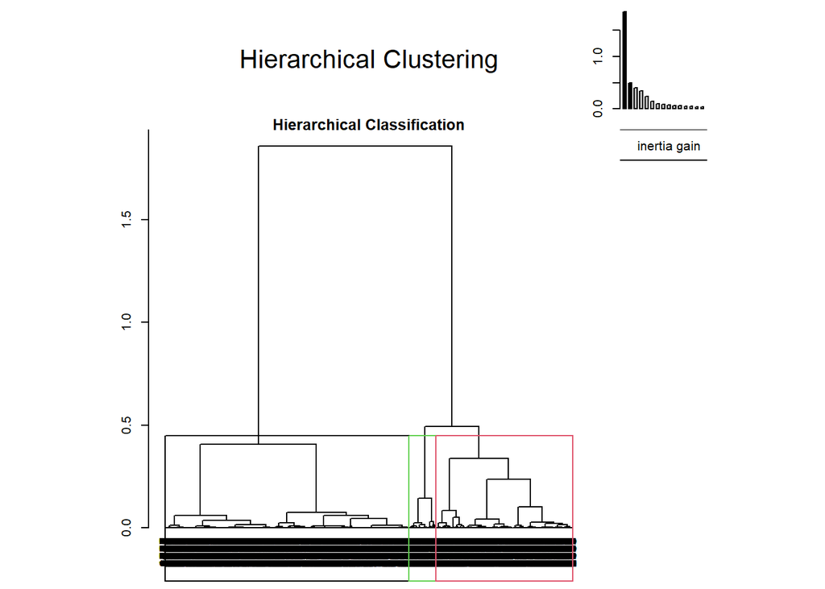

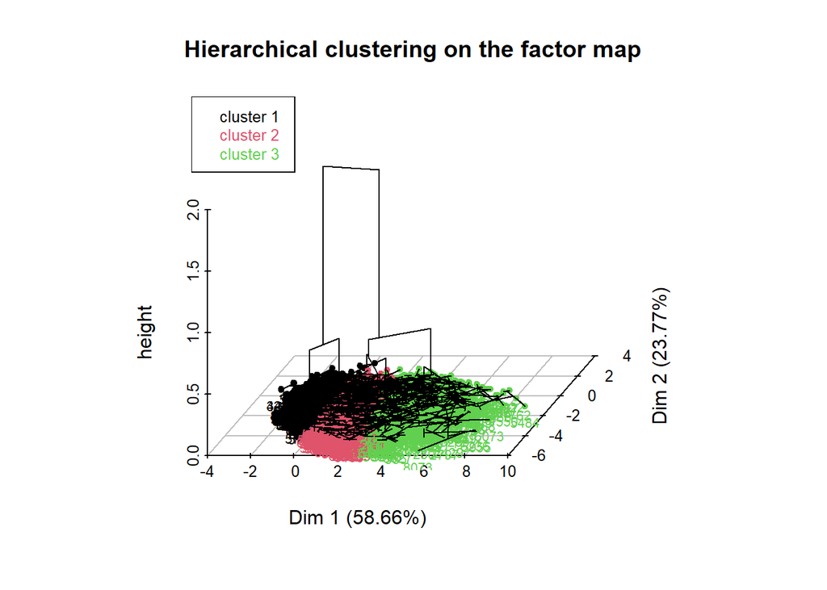

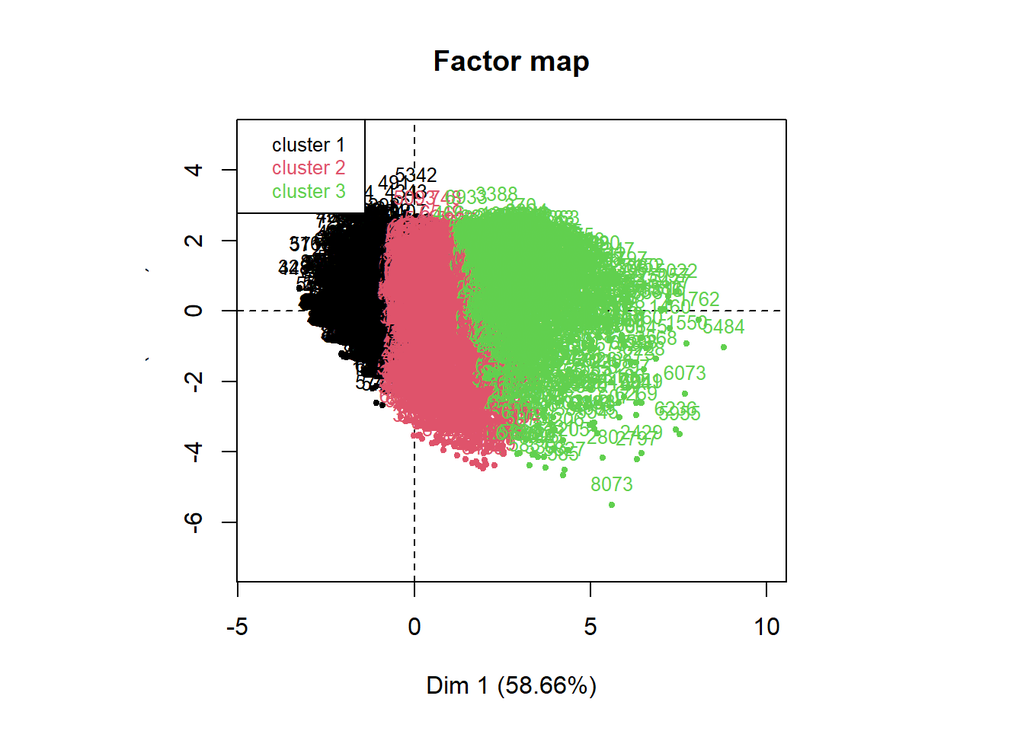

```r
Cluster_viviendas <- HCPC(pca_model_FactorM,nb.clust=-1)
```

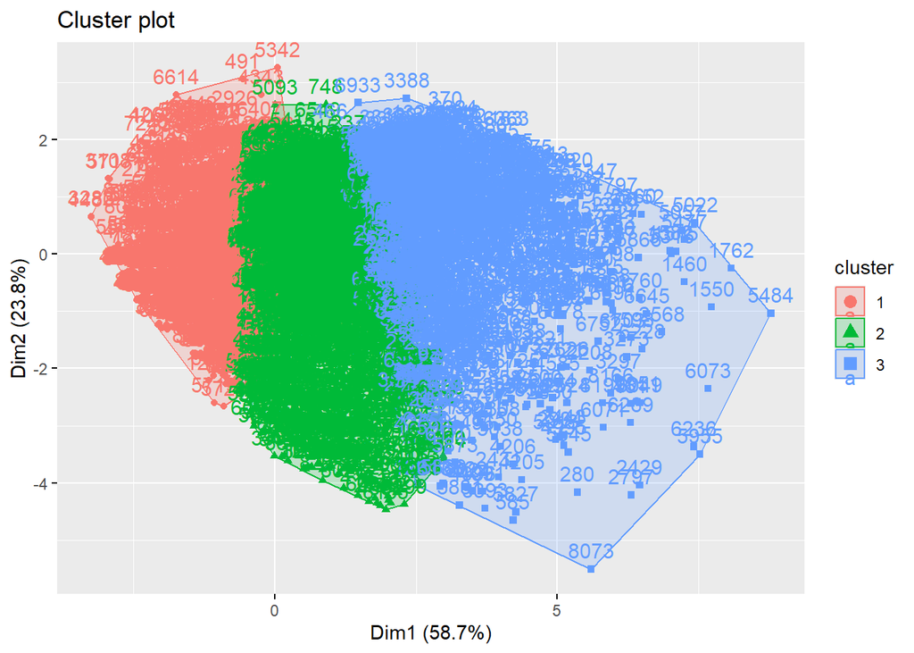

```r
fviz_cluster(Cluster_viviendas,respel = T)#para generar gráfico de cluster.
```

**Figura 12. Clúster generados por la librería FactoMineR**

### 5.2 Clúster por variables cuantitativas

Tabla 4. Descripción de cada clúster por variables cuantitativas

```r
Cluster_viviendas$desc.var$quanti
```

```
## $`1`
##                 v.test Mean in category Overall mean sd in category Overall sd
## estrato      -43.44906         4.162000     4.633610      0.8549785   1.029160
## habitaciones -48.30433         2.861838     3.605361      0.7381741   1.459449
## areaconst    -55.11171        91.841900   174.934938     43.7281648 142.955533
## preciom      -57.59277       234.279333   433.904436    100.0212103 328.645270
## banios       -67.65133         2.092340     3.111311      0.6168498   1.428124
##              p.value
## estrato            0
## habitaciones       0
## areaconst          0
## preciom            0
## banios             0
##
## $`2`
##                v.test Mean in category Overall mean sd in category Overall sd
## banios       32.27378         3.805623     3.111311      0.8878737   1.428124
## habitaciones 30.42291         4.274210     3.605361      1.5358014   1.459449
## estrato      21.77490         4.971191     4.633610      0.9863013   1.029160
## areaconst    13.55570       204.126768   174.934938     83.3716172 142.955533
## preciom      10.73560       487.053107   433.904436    168.5907294 328.645270
##                    p.value
## banios       1.632046e-228
## habitaciones 2.734945e-203
## estrato      4.013585e-105
## areaconst     7.331275e-42
## preciom       6.926408e-27
##
## $`3`
##                v.test Mean in category Overall mean sd in category Overall sd
## preciom      69.41544      1069.051030   433.904436    357.1253452 328.645270
## areaconst    61.84414       421.079391   174.934938    193.3465913 142.955533
## banios       54.09829         5.262310     3.111311      1.3408209   1.428124
## estrato      33.28343         5.587287     4.633610      0.6983415   1.029160
## habitaciones 28.32988         4.756491     3.605361      1.7476843   1.459449
##                    p.value
## preciom       0.000000e+00
## areaconst     0.000000e+00
## banios        0.000000e+00
## estrato      6.707168e-243
## habitaciones 1.481562e-176
```

El análisis de conglomerados (Figura 12, tabla 4) permitió identificar tres segmentos claramente diferenciados en el mercado inmobiliario. El primer cluster corresponde a viviendas de bajo valor, caracterizadas por menor área construida, menor número de baños y habitaciones y ubicadas en estratos socioeconómicos bajos. El segundo cluster representa el mercado medio, con viviendas de tamaño y precio moderado, orientadas a hogares familiares. El tercer cluster agrupa propiedades de alta gama, con mayor área construida, más servicios y ubicadas en estratos altos, presentando precios significativamente superiores al promedio. Las diferencias entre los clusters son estadísticamente significativas, lo que confirma la existencia de una estructura segmentada en la oferta inmobiliaria urbana.

### 5.3 Análisis de Correspondencia

Al realizar el análisis entre zona y tipo, solo surge una dimensión, por lo que se decide realizar un análisis tridimensional entre: zona, tipo y estrato.

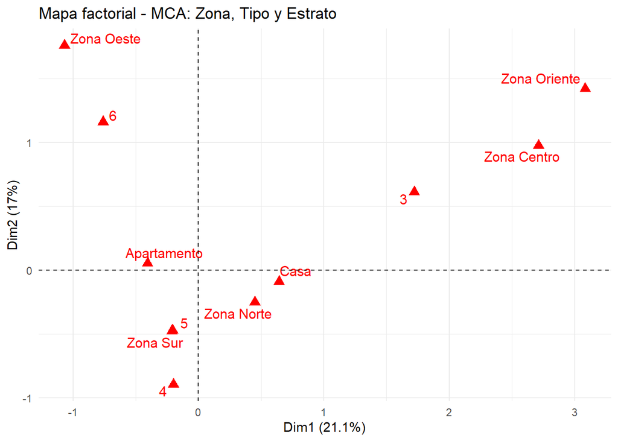

```r
df_cuali <- df_sin_coord %>%
  mutate(estrato = factor(estrato))%>%
  select(zona, tipo, estrato)

res_MCA <- MCA(df_cuali, graph = FALSE)

fviz_mca_biplot(
  res_MCA,
  repel = TRUE,
  invisible = "ind",   # oculta los 8319 puntos
  col.var = "red",     # categorías en rojo
  pointsize = 3,
  labelsize = 4,
  title = "Mapa factorial - MCA: Zona, Tipo y Estrato"
) +
  theme_minimal()
```

**Figura 13. Análisis de correspondencias múltiples**

El análisis de correspondencias múltiples (figura 13) evidencia una asociación entre el tipo de inmueble, la zona y el estrato socioeconómico. Se observa que los apartamentos se concentran principalmente en zonas del sur con estratos medios (4 y 5), mientras que las casas presentan mayor presencia en las zonas norte, centro y oriente, asociadas a estratos medios y bajos. La zona oeste se relaciona con el estrato 6, lo que sugiere una concentración de viviendas de alto nivel socioeconómico en esta área. Estos resultados confirman la existencia de una especialización territorial de la oferta inmobiliaria y complementan la segmentación identificada mediante el análisis de conglomerados.

## 7 Recomendaciones para la empresa inmobiliaria

1. Priorizar proyectos en segmento medio, mayor liquidez.
2. Mantener portafolio premium para rentabilidad.
3. Evitar sobreoferta en segmento bajo sin estrategia de volumen.

## 8 Conclusión final

Estos hallazgos permiten a la empresa optimizar su portafolio, focalizar la inversión en el segmento medio como motor de liquidez, desarrollar proyectos premium en zonas de alto valor y estructurar modelos de valoración basados en atributos físicos del inmueble, generando una ventaja competitiva en la toma de decisiones estratégicas.

## 9 Anexos

### 9.1 Dataset depurado

El dataset depurado contiene 8.319 registros y variables estructurales del inmueble, incluyendo atributos físicos, socioeconómicos y espaciales. La tabla 5 permite explorar de forma interactiva la información utilizada en los análisis multivariados.

|  | id | zona | piso | estrato | preciom | areaconst | parqueaderos | banios | habitaciones | tipo | barrio | longitud | latitud |
| --- | --- | --- | --- | --- | --- | --- | --- | --- | --- | --- | --- | --- | --- |
| 1 | 1147 | Zona Oriente | No informado | 3 | 250 | 70 | 1 | 3 | 6 | Casa | 20 de julio | -76.51168 | 3.43382 |
| 2 | 1169 | Zona Oriente | No informado | 3 | 320 | 120 | 1 | 2 | 3 | Casa | 20 de julio | -76.51237 | 3.43369 |
| 3 | 1350 | Zona Oriente | No informado | 3 | 350 | 220 | 2 | 2 | 4 | Casa | 20 de julio | -76.51537 | 3.43566 |
| 4 | 5992 | Zona Sur | 02 | 4 | 400 | 280 | 3 | 5 | 3 | Casa | 3 de julio | -76.54 | 3.435 |
| 5 | 1212 | Zona Norte | 01 | 5 | 260 | 90 | 1 | 2 | 3 | Apartamento | acopi | -76.5135 | 3.45891 |
| 6 | 1724 | Zona Norte | 01 | 5 | 240 | 87 | 1 | 3 | 3 | Apartamento | acopi | -76.517 | 3.36971 |
| 7 | 2326 | Zona Norte | 01 | 4 | 220 | 52 | 2 | 2 | 3 | Apartamento | acopi | -76.51974 | 3.42627 |
| 8 | 4386 | Zona Norte | 01 | 5 | 310 | 137 | 2 | 3 | 4 | Apartamento | acopi | -76.53105 | 3.38296 |
| 9 | 1209 | Zona Norte | 02 | 5 | 320 | 150 | 2 | 4 | 6 | Casa | acopi | -76.51341 | 3.47968 |
| 10 | 1592 | Zona Norte | 02 | 5 | 780 | 380 | 2 | 3 | 3 | Casa | acopi | -76.51674 | 3.48721 |

[output cut: 8309 more lines]